# Machine Learning HW04

소프트웨어융합학과 2018102111 서보민

You can load the dataset with ‘fetch_openml(‘credit-g’)’ and can find it’s description at https://www.openml.org/d/31. The goal is to classify the ‘class (target)’ column – binary classification.

```python
import matplotlib.pyplot as plt
%matplotlib inline
import numpy as np
import pandas as pd
import sklearn
```

1. (5 pts) Determine which features are continuous and which are categorical.

```python
credit = pd.read_csv("credit-g.csv")
categorical = credit.dtypes == object
continuous = credit.loc[:, ~categorical]
contype = credit.dtypes == credit[continuous.columns[0]].dtypes
categorical = credit.loc[:, ~contype]
categorical = categorical.drop(categorical.columns[13], axis = 1)
```

```python
continuous
```

|  | duration | credit_amount | installment_commitment | residence_since | age | existing_credits | num_dependents |
| --- | --- | --- | --- | --- | --- | --- | --- |
| 0 | 6 | 1169 | 4 | 4 | 67 | 2 | 1 |
| 1 | 48 | 5951 | 2 | 2 | 22 | 1 | 1 |
| 2 | 12 | 2096 | 2 | 3 | 49 | 1 | 2 |
| 3 | 42 | 7882 | 2 | 4 | 45 | 1 | 2 |
| 4 | 24 | 4870 | 3 | 4 | 53 | 2 | 2 |
| ... | ... | ... | ... | ... | ... | ... | ... |
| 995 | 12 | 1736 | 3 | 4 | 31 | 1 | 1 |
| 996 | 30 | 3857 | 4 | 4 | 40 | 1 | 1 |
| 997 | 12 | 804 | 4 | 4 | 38 | 1 | 1 |
| 998 | 45 | 1845 | 4 | 4 | 23 | 1 | 1 |
| 999 | 45 | 4576 | 3 | 4 | 27 | 1 | 1 |

1000 rows × 7 columns

```python
categorical
```

|  | checking_status | credit_history | purpose | savings_status | employment | personal_status | other_parties | property_magnitude | other_payment_plans | housing | job | own_telephone | foreign_worker |
| --- | --- | --- | --- | --- | --- | --- | --- | --- | --- | --- | --- | --- | --- |
| 0 | '<0' | 'critical/other existing credit' | radio/tv | 'no known savings' | '>=7' | 'male single' | none | 'real estate' | none | own | skilled | yes | yes |
| 1 | '0<=X<200' | 'existing paid' | radio/tv | '<100' | '1<=X<4' | 'female div/dep/mar' | none | 'real estate' | none | own | skilled | none | yes |
| 2 | 'no checking' | 'critical/other existing credit' | education | '<100' | '4<=X<7' | 'male single' | none | 'real estate' | none | own | 'unskilled resident' | none | yes |
| 3 | '<0' | 'existing paid' | furniture/equipment | '<100' | '4<=X<7' | 'male single' | guarantor | 'life insurance' | none | 'for free' | skilled | none | yes |
| 4 | '<0' | 'delayed previously' | 'new car' | '<100' | '1<=X<4' | 'male single' | none | 'no known property' | none | 'for free' | skilled | none | yes |
| ... | ... | ... | ... | ... | ... | ... | ... | ... | ... | ... | ... | ... | ... |
| 995 | 'no checking' | 'existing paid' | furniture/equipment | '<100' | '4<=X<7' | 'female div/dep/mar' | none | 'real estate' | none | own | 'unskilled resident' | none | yes |
| 996 | '<0' | 'existing paid' | 'used car' | '<100' | '1<=X<4' | 'male div/sep' | none | 'life insurance' | none | own | 'high qualif/self emp/mgmt' | yes | yes |
| 997 | 'no checking' | 'existing paid' | radio/tv | '<100' | '>=7' | 'male single' | none | car | none | own | skilled | none | yes |
| 998 | '<0' | 'existing paid' | radio/tv | '<100' | '1<=X<4' | 'male single' | none | 'no known property' | none | 'for free' | skilled | yes | yes |
| 999 | '0<=X<200' | 'critical/other existing credit' | 'used car' | '100<=X<500' | unemployed | 'male single' | none | car | none | own | skilled | none | yes |

1000 rows × 13 columns

1. (10 pts) Visualize the univariate distribution of each continuous feature, and the distribution of the target.

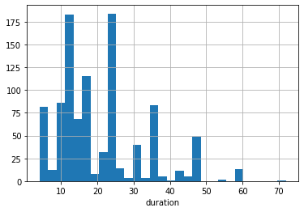

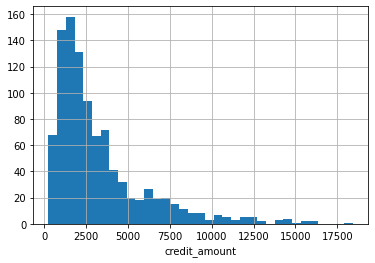

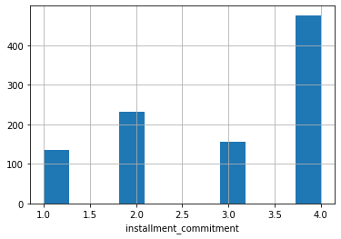

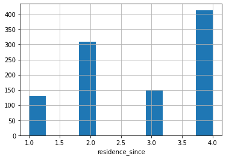

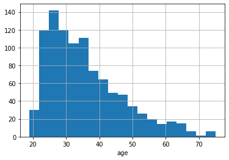

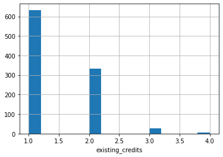

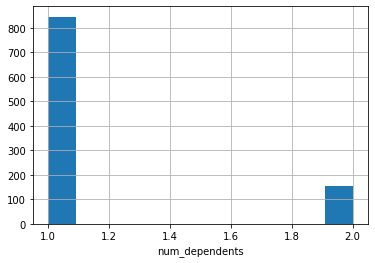

```python
i = 0
for i in range(0,len(continuous.columns)):
    continuous[continuous.columns[i]].hist(bins = 'auto')
    plt.xlabel(continuous.columns[i])
    plt.show()
    i += 1
```

1. (10 pts) Split data into training (70%), validation (10%), and test set (20%). Do not use the test set until a final evaluation in 5. Preprocess the data without using a pipeline and evaluate an initial Logistic Regression model with the training and validation split.

```python
from sklearn.linear_model import LogisticRegression
from sklearn.model_selection import train_test_split, cross_val_score
from sklearn.preprocessing import StandardScaler, LabelEncoder, OneHotEncoder

mapping = { 'good' : 1, 'bad' : -1}
credit['class'] = credit['class'].map(mapping)

X = credit.drop('class', axis = 1)
y = credit['class'].values

le = LabelEncoder()
k = 0
for k in range(len(categorical.columns)):
    X[categorical.columns[k]] = le.fit_transform(X[categorical.columns[k]])
    k += 1

X_temp, X_test, y_temp, y_test = \
        train_test_split(X, y, test_size=0.2,
                         shuffle=True, random_state=123, stratify=y)
X_train, X_valid, y_train, y_valid = \
        train_test_split(X_temp, y_temp, test_size=0.125,
                         shuffle=True, random_state=123, stratify=y_temp)
```

```python
std = StandardScaler()
logreg = LogisticRegression(C = 1, max_iter=10000)

X_train_std = std.fit_transform(X_train)
X_valid_std = std.fit_transform(X_valid)

acc = logreg.fit(X_train_std, y_train)
print("train-set accuracy : ", acc.score(X_train_std,y_train))
print("valid-set accuracy : ", acc.score(X_valid_std,y_valid))
```

```
train-set accuracy :  0.7328571428571429
valid-set accuracy :  0.71
```

1. (15 pts) Use ColumnTransformer and pipeline to encode categorical variables (your choice of OneHotEncoder or another one from the categorical_encoder package, or both). Evaluate Logistic Regression, Linear Support Vector Machines and Random Forests using cross-validation. How different are the results? How does scaling the continuous features with StandardScaler influence the results?

```python
from sklearn.impute import SimpleImputer
from sklearn.compose import make_column_transformer, make_column_selector
from sklearn.pipeline import make_pipeline
from sklearn.svm import SVC
from sklearn.tree import DecisionTreeClassifier
from sklearn.ensemble import RandomForestClassifier
```

```python
cat_preprocessing = make_pipeline(SimpleImputer(strategy='constant', fill_value='NA'),
                                  OneHotEncoder(handle_unknown='ignore'))
cont_preprocessing = make_pipeline(SimpleImputer(), StandardScaler())
preprocess = make_column_transformer((cat_preprocessing, make_column_selector(dtype_include='object')),
                                      remainder=cont_preprocessing)
```

```python
credit1 = pd.read_csv("credit-g.csv")
X1 = credit1.drop('class', axis = 1)
y1 = credit1['class'].values
X1_temp, X1_test, y1_temp, y1_test = \
        train_test_split(X1, y1, test_size=0.2,
                         shuffle=True, random_state=123, stratify=y)
X1_train, X1_valid, y1_train, y1_valid = \
        train_test_split(X1_temp, y1_temp, test_size=0.125,
                         shuffle=True, random_state=123, stratify=y_temp)
```

```python
print("LogisticRegression accuracy, train_set :\n",cross_val_score(make_pipeline(preprocess, LogisticRegression(C = 1, max_iter=10000)), X1_train, y1_train, cv=5))
print("LogisticRegression accuracy, valid_set :\n",cross_val_score(make_pipeline(preprocess, LogisticRegression(C = 1, max_iter=10000)), X1_valid, y1_valid, cv=5))
print("Linear Support Vector Machines accuracy, train_set :\n",cross_val_score(make_pipeline(preprocess, SVC(kernel = 'linear')), X1_train, y1_train, cv=5))
print("Linear Support Vector Machines accuracy, valid_set :\n",cross_val_score(make_pipeline(preprocess, SVC(kernel = 'linear')), X1_valid, y1_valid, cv=5))
print("Random Forests accuracy, train_set :\n",cross_val_score(make_pipeline(preprocess, RandomForestClassifier(random_state=0)), X1_train, y1_train, cv=5))
print("Random Forests accuracy, valid_set :\n",cross_val_score(make_pipeline(preprocess, RandomForestClassifier(random_state=0)), X1_valid, y1_valid, cv=5))
```

```
LogisticRegression accuracy, train_set :
 [0.74285714 0.77142857 0.75714286 0.8        0.75      ]
LogisticRegression accuracy, valid_set :
 [0.65 0.5  0.65 0.65 0.6 ]
Linear Support Vector Machines accuracy, train_set :
 [0.75       0.75       0.73571429 0.77142857 0.74285714]
Linear Support Vector Machines accuracy, valid_set :
 [0.6  0.55 0.6  0.7  0.65]
Random Forests accuracy, train_set :
 [0.74285714 0.76428571 0.77142857 0.80714286 0.76428571]
Random Forests accuracy, valid_set :
 [0.75 0.6  0.7  0.7  0.7 ]
```

```python
cat_preprocessing = make_pipeline(SimpleImputer(strategy='constant', fill_value='NA'),
                                  OneHotEncoder(handle_unknown='ignore'))
cont_preprocessing = make_pipeline(SimpleImputer())
preprocess = make_column_transformer((cat_preprocessing, make_column_selector(dtype_include='object')),
                                      remainder=cont_preprocessing)

print("LogisticRegression accuracy, train_set :\n",cross_val_score(make_pipeline(preprocess, LogisticRegression(C = 1, max_iter=10000)), X1_train, y1_train, cv=5))
print("LogisticRegression accuracy, valid_set :\n",cross_val_score(make_pipeline(preprocess, LogisticRegression(C = 1, max_iter=10000)), X1_valid, y1_valid, cv=5))
print("Linear Support Vector Machines accuracy, train_set :\n",cross_val_score(make_pipeline(preprocess, SVC(kernel = 'linear')), X1_train, y1_train, cv=5))
print("Linear Support Vector Machines accuracy, valid_set :\n",cross_val_score(make_pipeline(preprocess, SVC(kernel = 'linear')), X1_valid, y1_valid, cv=5))
print("Random Forests accuracy, train_set :\n",cross_val_score(make_pipeline(preprocess, RandomForestClassifier(random_state=0)), X1_train, y1_train, cv=5))
print("Random Forests accuracy, valid_set :\n",cross_val_score(make_pipeline(preprocess, RandomForestClassifier(random_state=0)), X1_valid, y1_valid, cv=5))
```

```
LogisticRegression accuracy, train_set :
 [0.73571429 0.77857143 0.75       0.76428571 0.76428571]
LogisticRegression accuracy, valid_set :
 [0.7 0.4 0.7 0.7 0.6]
Linear Support Vector Machines accuracy, train_set :
 [0.71428571 0.73571429 0.73571429 0.79285714 0.77857143]
Linear Support Vector Machines accuracy, valid_set :
 [0.6  0.55 0.6  0.7  0.6 ]
Random Forests accuracy, train_set :
 [0.73571429 0.76428571 0.77142857 0.80714286 0.76428571]
Random Forests accuracy, valid_set :
 [0.75 0.6  0.7  0.75 0.7 ]
```

1. (15 pts) Tune the parameters using GridSearchCV. Do the results improve? Evaluate only the be model on the test set. And visualize the performance as function of the parameters for all three models.

```python
from sklearn.model_selection import GridSearchCV, RepeatedKFold, RepeatedStratifiedKFold
classifier = SVC(kernel = 'linear')
logreg = LogisticRegression(C = 1, max_iter=10000)
rfc = RandomForestClassifier(random_state=0)

c_values = np.arange(0.1,10,0.1)
param_grid = dict(C=c_values)
grid = GridSearchCV(logreg, param_grid = param_grid,
                          cv = RepeatedStratifiedKFold(n_splits=5, n_repeats=3), return_train_score=True)
grid.fit(X_train,y_train)
print(f"best parameters: {grid.best_params_}")

print(f"test-set score: {grid.score(X_test, y_test):.3f}")
```

```
best parameters: {'C': 0.1}
test-set score: 0.715
```

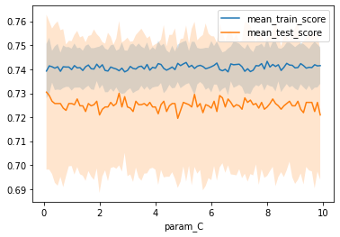

```python
results = pd.DataFrame(grid.cv_results_)
results.plot('param_C', 'mean_train_score')
results.plot('param_C', 'mean_test_score', ax=plt.gca())
plt.fill_between(results.param_C.astype(np.float64),
                 results['mean_train_score'] + results['std_train_score'],
                 results['mean_train_score'] - results['std_train_score'], alpha=0.2)
plt.fill_between(results.param_C.astype(np.float64),
                 results['mean_test_score'] + results['std_test_score'],
                 results['mean_test_score'] - results['std_test_score'], alpha=0.2)
plt.legend()
```

```python
a_train = std.fit_transform(X_train)
a_test = std.fit_transform(X_test)
```

```python
param_grid2 = { 'C': np.arange(0.1,50,0.5), 'gamma': [0.1]}
grid2 = GridSearchCV(classifier, param_grid = param_grid2,
                          cv = RepeatedStratifiedKFold(n_splits=3, n_repeats=3), return_train_score=True)
grid2.fit(a_train,y_train)
print(f"best parameters: {grid2.best_params_}")

print(f"test-set score: {grid2.score(a_test, y_test):.3f}")
```

```
best parameters: {'C': 0.1, 'gamma': 0.1}
test-set score: 0.750
```

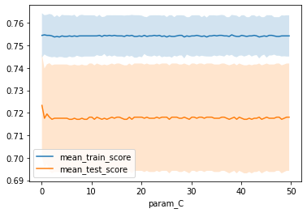

```python
results2 = pd.DataFrame(grid2.cv_results_)
results2.plot('param_C','mean_train_score')
results2.plot('param_C','mean_test_score', ax=plt.gca())
plt.fill_between(results2.param_C.astype(np.float64),
                 results2['mean_train_score'] + results2['std_train_score'],
                 results2['mean_train_score'] - results2['std_train_score'], alpha=0.2)
plt.fill_between(results2.param_C.astype(np.float64),
                 results2['mean_test_score'] + results2['std_test_score'],
                 results2['mean_test_score'] - results2['std_test_score'], alpha=0.2)
plt.legend()
```

```python
max_depth = np.arange(1,20,1)
param_grid3 = {'max_depth': max_depth }
grid3 = GridSearchCV(rfc, param_grid = param_grid3,
                          cv = RepeatedStratifiedKFold(n_splits=5, n_repeats=3), return_train_score=True)
grid3.fit(a_train,y_train)
print(f"best parameters: {grid3.best_params_}")

print(f"test-set score: {grid3.score(a_test, y_test):.3f}")
```

```
best parameters: {'max_depth': 16}
test-set score: 0.715
```

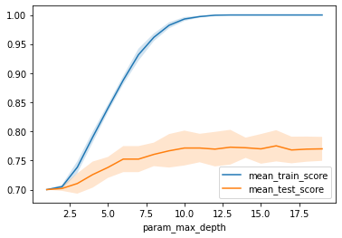

```python
results3 = pd.DataFrame(grid3.cv_results_)
results3.plot('param_max_depth', 'mean_train_score')
results3.plot('param_max_depth', 'mean_test_score', ax=plt.gca())
plt.fill_between(results3.param_max_depth.astype(np.float64),
                 results3['mean_train_score'] + results3['std_train_score'],
                 results3['mean_train_score'] - results3['std_train_score'], alpha=0.2)
plt.fill_between(results3.param_max_depth.astype(np.float64),
                 results3['mean_test_score'] + results3['std_test_score'],
                 results3['mean_test_score'] - results3['std_test_score'], alpha=0.2)
plt.legend()
```

```python
param_grid3 = {'n_estimators' : np.arange(1,100,5) }
grid3 = GridSearchCV(rfc, param_grid = param_grid3,
                          cv = RepeatedStratifiedKFold(n_splits=5, n_repeats=3), return_train_score=True)
grid3.fit(a_train,y_train)
print(f"best parameters: {grid3.best_params_}")

print(f"test-set score: {grid3.score(a_test, y_test):.3f}")
```

```
best parameters: {'n_estimators': 86}
test-set score: 0.720
```

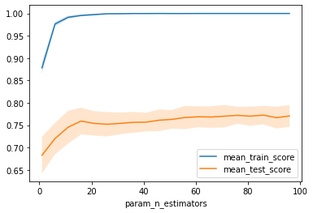

```python
results3 = pd.DataFrame(grid3.cv_results_)
results3.plot('param_n_estimators', 'mean_train_score')
results3.plot('param_n_estimators', 'mean_test_score', ax=plt.gca())
plt.fill_between(results3.param_n_estimators.astype(np.float64),
                 results3['mean_train_score'] + results3['std_train_score'],
                 results3['mean_train_score'] - results3['std_train_score'], alpha=0.2)
plt.fill_between(results3.param_n_estimators.astype(np.float64),
                 results3['mean_test_score'] + results3['std_test_score'],
                 results3['mean_test_score'] - results3['std_test_score'], alpha=0.2)
plt.legend()
```

1. (15 pts) Change the cross-validation strategy from ‘stratified k-fold’ to ‘kfold’ with shuffling. Do the parameters that are found change? Do they change if you change the random seed of the shuffling? Or if you change the random state of the split into training and test data?

```python
X2_temp, X2_test, y2_temp, y2_test = \
        train_test_split(X, y, test_size=0.2,
                         shuffle=True, random_state=123)
X2_train, X2_valid, y2_train, y2_valid = \
        train_test_split(X2_temp, y2_temp, test_size=0.125,
                         shuffle=True, random_state=123)
```

```python
c_values = np.arange(0.1,10,0.1)
param_grid = dict(C=c_values)
grid = GridSearchCV(logreg, param_grid = param_grid,
                          cv = RepeatedKFold(n_splits=5, n_repeats=3), return_train_score=True)
grid.fit(X2_train,y2_train)
print(f"best parameters: {grid.best_params_}")

print(f"test-set score: {grid.score(X2_test, y2_test):.3f}")
```

```
best parameters: {'C': 9.3}
test-set score: 0.735
```

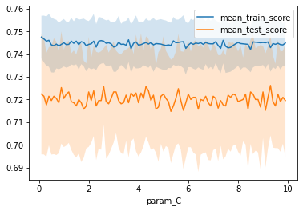

```python
results = pd.DataFrame(grid.cv_results_)
results.plot('param_C', 'mean_train_score')
results.plot('param_C', 'mean_test_score', ax=plt.gca())
plt.fill_between(results.param_C.astype(np.float64),
                 results['mean_train_score'] + results['std_train_score'],
                 results['mean_train_score'] - results['std_train_score'], alpha=0.2)
plt.fill_between(results.param_C.astype(np.float64),
                 results['mean_test_score'] + results['std_test_score'],
                 results['mean_test_score'] - results['std_test_score'], alpha=0.2)
plt.legend()
```

```python
X2_temp, X2_test, y2_temp, y2_test = \
        train_test_split(X, y, test_size=0.2,
                         shuffle=True, random_state=100)
X2_train, X2_valid, y2_train, y2_valid = \
        train_test_split(X2_temp, y2_temp, test_size=0.125,
                         shuffle=True, random_state=100)
```

```python
c_values = np.arange(0.1,10,0.1)
param_grid = dict(C=c_values)
grid = GridSearchCV(logreg, param_grid = param_grid,
                          cv = RepeatedKFold(n_splits=5, n_repeats=3), return_train_score=True)
grid.fit(X2_train,y2_train)
print(f"best parameters: {grid.best_params_}")

print(f"test-set score: {grid.score(X2_test, y2_test):.3f}")
```

```
best parameters: {'C': 7.3}
test-set score: 0.720
```

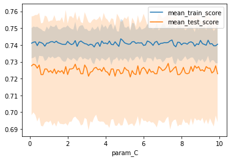

```python
results = pd.DataFrame(grid.cv_results_)
results.plot('param_C', 'mean_train_score')
results.plot('param_C', 'mean_test_score', ax=plt.gca())
plt.fill_between(results.param_C.astype(np.float64),
                 results['mean_train_score'] + results['std_train_score'],
                 results['mean_train_score'] - results['std_train_score'], alpha=0.2)
plt.fill_between(results.param_C.astype(np.float64),
                 results['mean_test_score'] + results['std_test_score'],
                 results['mean_test_score'] - results['std_test_score'], alpha=0.2)
plt.legend()
```

1. (10 pts) Visualize the 20 most important coefficients for Logistic Regression and Linear Support Vector Machines using hyper-parameters that performed well in the grid-search.

```python
classifier = SVC(kernel = 'linear', C = 0.1, gamma = 0.1)
logreg = LogisticRegression(C = 0.1, max_iter=10000)
coef = logreg.fit(X_train,y_train)
coef2 = classifier.fit(X_train,y_train)
print(coef.coef_, coef.intercept_)
print(coef2.coef_, coef2.intercept_)
```

```
[[ 5.29295408e-01 -2.98932254e-02 -1.03677909e-01  1.25398969e-01
  -8.47596871e-05  1.31376119e-01 -4.23235578e-02 -2.99691127e-01
   2.68102948e-01  4.33748080e-02  1.61589987e-02  1.23926654e-01
   1.52349116e-02  3.31111071e-01 -1.03157627e-01  4.44177488e-02
  -4.61415319e-02 -5.59065831e-02  1.96144722e-01 -1.33277747e-01]] [0.04886502]
[[ 5.40488034e-01 -4.77406501e-02 -2.14078361e-01  1.05491828e-01
  -5.83477431e-05  1.47311448e-01 -5.59868225e-02 -3.52939150e-01
   3.29953784e-01 -1.22829307e-02  2.93613297e-02  1.42085320e-01
   2.91279441e-03  2.82730513e-01 -3.45413115e-01 -1.49350031e-01
  -1.12682842e-01 -6.10011799e-02  2.22360610e-01 -2.43003590e-01]] [2.0616039]
```

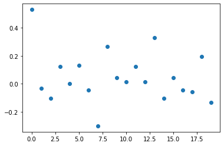

```python
df = pd.DataFrame(coef.coef_)
plt.scatter(df.columns,df.values)
```

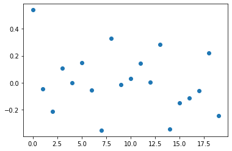

```python
df2 = pd.DataFrame(coef2.coef_)
plt.scatter(df2.columns,df2.values)
```

1. (10 pts) Using optimized models that performed well in the grid-search, compute the performance of all three models using confusion matrix, precision, recall, and F1-score. How different are the results? Also, calculate the true positive rate and false positive rate for all three models. Discuss the results.

```
[[ 22  38]
 [ 19 121]]
              precision    recall  f1-score   support

         bad       0.54      0.37      0.44        60
        good       0.76      0.86      0.81       140

    accuracy                           0.71       200
   macro avg       0.65      0.62      0.62       200
weighted avg       0.69      0.71      0.70       200

TPR :  0.864
FPR :  0.633
```

```
<sklearn.metrics._plot.confusion_matrix.ConfusionMatrixDisplay at 0x2029d541340>
```

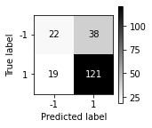

```python
from sklearn.metrics import confusion_matrix, plot_confusion_matrix
from sklearn.metrics import classification_report

lr = LogisticRegression(C =0.1, max_iter=10000).fit(X_train, y_train)
y_pred = lr.predict(X_test)
print(confusion_matrix(y_test, y_pred))
print(classification_report(y_test, y_pred, target_names=['bad', 'good']))
print(f'TPR :  {confusion_matrix(y_test, y_pred)[1][1]/confusion_matrix(y_test, y_pred)[1].sum():.3f}')
print(f'FPR :  {confusion_matrix(y_test, y_pred)[0][1]/confusion_matrix(y_test, y_pred)[0].sum():.3f}')

fig, ax = plt.subplots(figsize=(2, 2))
plot_confusion_matrix(lr, X_test, y_test, cmap='gray_r', ax=ax)
```

```
[[ 21  39]
 [ 17 123]]
              precision    recall  f1-score   support

         bad       0.55      0.35      0.43        60
        good       0.76      0.88      0.81       140

    accuracy                           0.72       200
   macro avg       0.66      0.61      0.62       200
weighted avg       0.70      0.72      0.70       200

TPR :  0.879
FPR :  0.650
```

```
<sklearn.metrics._plot.confusion_matrix.ConfusionMatrixDisplay at 0x2029c4e16a0>
```

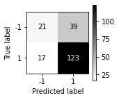

```python
svm = SVC(kernel = 'linear',C = 0.1, gamma = 0.1).fit(X_train, y_train)
y_pred2 = svm.predict(X_test)
print(confusion_matrix(y_test, y_pred2))
print(classification_report(y_test, y_pred2, target_names=['bad', 'good']))
print(f'TPR :  {confusion_matrix(y_test, y_pred2)[1][1]/confusion_matrix(y_test, y_pred2)[1].sum():.3f}')
print(f'FPR :  {confusion_matrix(y_test, y_pred2)[0][1]/confusion_matrix(y_test, y_pred2)[0].sum():.3f}')
fig, ax = plt.subplots(figsize=(2, 2))
plot_confusion_matrix(svm, X_test, y_test, cmap='gray_r', ax=ax)
```

```
[[ 26  34]
 [ 18 122]]
              precision    recall  f1-score   support

         bad       0.59      0.43      0.50        60
        good       0.78      0.87      0.82       140

    accuracy                           0.74       200
   macro avg       0.69      0.65      0.66       200
weighted avg       0.72      0.74      0.73       200

TPR :  0.871
FPR :  0.567
```

```
<sklearn.metrics._plot.confusion_matrix.ConfusionMatrixDisplay at 0x2029d81e910>
```

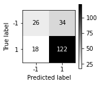

```python
rf = RandomForestClassifier(max_depth = 16).fit(X_train, y_train)
y_pred3 = rf.predict(X_test)
print(confusion_matrix(y_test, y_pred3))
print(classification_report(y_test, y_pred3, target_names=['bad', 'good']))
print(f'TPR :  {confusion_matrix(y_test, y_pred3)[1][1]/confusion_matrix(y_test, y_pred3)[1].sum():.3f}')
print(f'FPR :  {confusion_matrix(y_test, y_pred3)[0][1]/confusion_matrix(y_test, y_pred3)[0].sum():.3f}')
fig, ax = plt.subplots(figsize=(2, 2))
plot_confusion_matrix(rf, X_test, y_test, cmap='gray_r', ax=ax)
```

1. (10 pts) Plot precision-recall (PR) curve and receiver operating characteristics (ROC) curve for all three models. Also, compute the performance of all three models using average precision and area under the curve (AUC). Discuss the results.

```
<sklearn.metrics._plot.precision_recall_curve.PrecisionRecallDisplay at 0x2029d91e4f0>
```

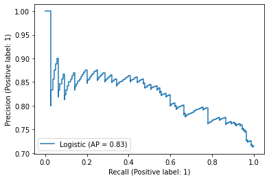

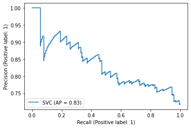

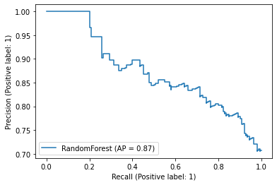

```python
from sklearn.metrics import plot_precision_recall_curve, auc, plot_roc_curve

plot_precision_recall_curve(lr, X_test, y_test, name = 'Logistic')
plot_precision_recall_curve(svm, X_test, y_test, name = 'SVC')
plot_precision_recall_curve(rf, X_test, y_test, name = 'RandomForest')
```

```
<sklearn.metrics._plot.roc_curve.RocCurveDisplay at 0x2029d8af700>
```

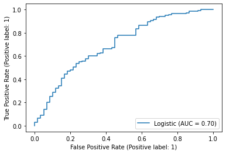

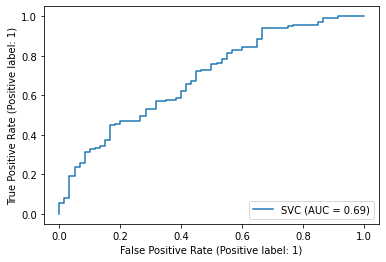

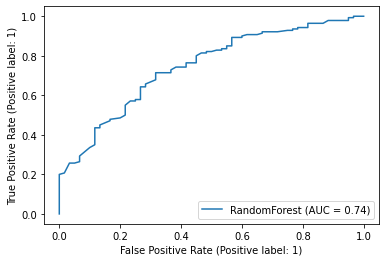

```python
plot_roc_curve(lr, X_test, y_test, name='Logistic')
plot_roc_curve(svm, X_test, y_test, name='SVC')
plot_roc_curve(rf, X_test, y_test, name = 'RandomForest')
```

```python
from sklearn.metrics import average_precision_score
ap_lr = average_precision_score(y_test, lr.decision_function(X_test))
ap_svc = average_precision_score(y_test, svm.decision_function(X_test))
ap_rf = average_precision_score(y_test, rf.predict_proba(X_test)[:, 1])
print("Average precision of Logistic: {:.3f}".format(ap_svc))
print("Average precision of SVC: {:.3f}".format(ap_svc))
print("Average precision of RandomForest: {:.3f}".format(ap_rf))
```

```
Average precision of Logistic: 0.833
Average precision of SVC: 0.833
Average precision of RandomForest: 0.872
```

```python
from sklearn import metrics

lr_auc = metrics.roc_auc_score(y_test, lr.decision_function(X_test))
print("AUC of Logistic: {:.3f}".format(lr_auc))
svc_auc = metrics.roc_auc_score(y_test, svm.decision_function(X_test))
print("AUC of SVC: {:.3f}".format(svc_auc))
rf_auc = metrics.roc_auc_score(y_test, rf.predict_proba(X_test)[:, 1])
print("AUC of RandomForest: {:.3f}".format(rf_auc))
```

```
AUC of Logistic: 0.700
AUC of SVC: 0.691
AUC of RandomForest: 0.744
```

The best model is RandomForest